# Google Analytics Case Study

**Jesus Martin** - *INSEAD MBA 15J*

jesus.martin.calvo@gmail.com

## Business motivation

Developing a digital strategy has become a need for any company, regardless of their core business. That involves creating the online experiences, including websites, applications, social media or any marketing technique that communicates effectively with the users. Whether it is to build a brand or sell a product, these actions need to be measured to understand its success and improve them. However, most companies struggle with this “digital analytics”.

One of the main tools to measure activity of users in a website or other digital experience is Google Analytics (GA). It is free and allows you to understand most aspects of their behavior. Companies use it with different purposes, varying from deciding which marketing investments they should continue or stop as well as what messages in social networks have a higher impact for their business.

This case will guide you to download some data from your GA account (if you do not have access to any, you can download some sample data from the website www.encortosabemejor.com) and show you some ways to understand how your website is performing in order to make managerial decisions. In this case it will help you to understand what content is generating higher user engagement so the company can focus on this type of content as well as understand whether this content should be focused on new readers so the community grows or to focus on existing readers so the community is more engaged.

In addition to that, this case addresses some of the most fundamental issues in Data Analysis and Visualization: getting data from a source, clean, summarize and visualize.

## Data Description

It is very important that you understand each of the columns, let's review its content

- **year**: the year the data was collected
- **month**: the month of the year the data was collected
- **pagePath**: the URL of the page which the data belongs to, excluding the domain.
- **source**: the website where the visitor was before landing into our website. If there was no website or it is not recognized, the value is (direct)
- **medium**: the mechanism by which the visitor landed in our website. Some values are: organic (search engine), cpc (paid advertising in search engines or other websites), referral (from other website), feed (from automated reading systems). If it is not recognized, the value is (none)
- **userType**: whether the user had been before in the website or not (New Visitor/Returning Visitor)
- **deviceCategory**: the device of the user
- **entrances**: how many times a user entered the website through that page
- **pageviews**: how many times a user opened that page
- **exits**: how many times that page was the last one opened by a user in the same session
- **timeOnPage**: how many seconds this page has been viewed
- **uniquePageviews**: how many times this page has been viewed in an unique session

From these columns we can have some derived metrics, for example:

- **Average time on page**= timeOnPage/(pageviews-exits)
- **Bounce rate**= exits/entrances
- **Exit rate**= exits/pageviews

## Introductory analysis

For example, we can visualize the seasonality of the visits per month, measured by the number of entrances

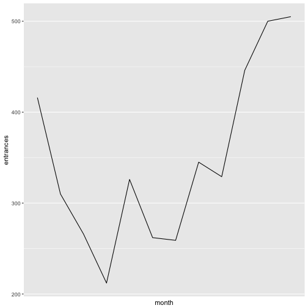

And its evolution year by year

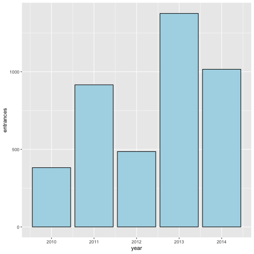

## Questions to solve

In this case study, you will have to answer five questions which will help the website to improve the content that is creating. You will need to modify and visualize the data. For these purposes, you can use the package “dplyr” (get more info with browseVignettes(package = “dplyr”) and the package “ggplot2” (get more info with ?ggplot or ?qplot)

1. What are the pages with more visits? Are them the same when medium is not 'cpc'? Can you make a recommendation on the most popular pages?

## *Answer 1*

First, let's see the column chart of entrances as Y-axis and pagePath as X-axis.

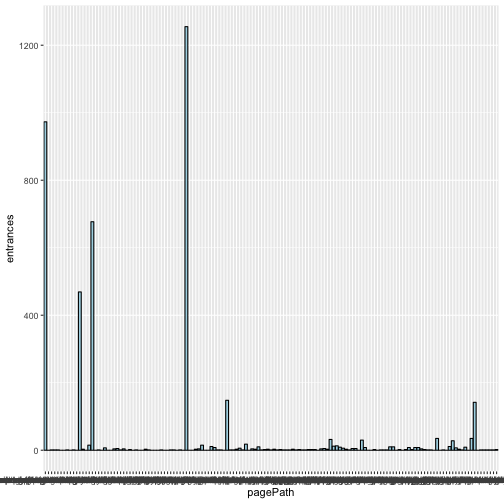

Note that only four pages have over 400 visits, out which one is 404-error page and one is the home page. The most popular pages have content regarding PHP and free software.

In order to let's understand which pages are visited via non-paid channels we will look at the most visited pages excluding lead by “cpc” medium

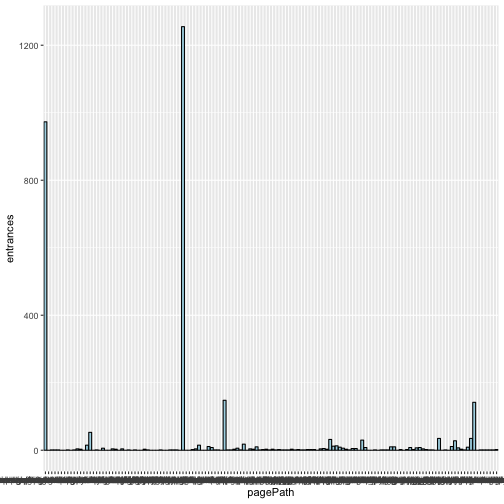

In this subset the top visited pages do not include 404-error page and Free Software page. After this analysis we can cay that the most popular pages are the PHP page, the home page and the free software page. This means that the editors should focus on these content topics in order to ensure growth of traffic to the website. This also means that there should be more content related to these topics on the home page to generate additional user engagement. We see many case where a 404-error page is visited via “cpc” medium. This indicates a “red flag” for online advertising of the website. Website owners are paying for lead generation to an empty page hence not bringing any additional traffic on these expenses. Website owners can use this data to make the online ad campaign more effective.

2 What are the exit rates for the pages with the most number of exits? How would you change the content of the page to reduce exit rate?

## *Answer 2*

Let's find the pages with the most number of exits

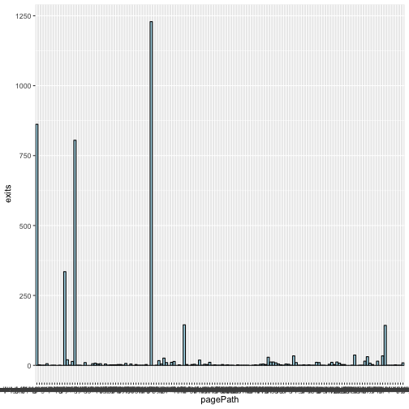

In order to calculate the Exit rate = # of Exits / # of pageviews we need to create a set which includes the abovementioned pagepaths and their respective cumulative pageviews and exits

#pages7 <- group_by(gadata, pagePath) %>% summarise(exits = sum(exits), pageviews = sum(pageviews))

In order to decrease exit rates the editors could do the following:

-improve quality of free software content adjusting this to customers tastes (using surveys or online research on this topic).It is obvious that free software generates user engagement (high number of visits), but the quality of the content may be poor which leads to high exit rates. -include PHP-related topics in the free software page as this content generates a lower exit rate -if the exits are driven by customer's intentions for new content on this topic, which they cannot find on the free software page then authors must include additional information on this topic in order not to lose traffic to other resources -improve website operational capabilities so that 404-error pages do not appear that often and implement automatic redirection to popular pages (ex. PHP).

3 What are the pages with the highest average time on page? Would you recommend the author to write more on these topics?

## *Answer 3*

We need to calculate and sort the pages according to the average time on page = timeOnPage/(pageviews-exits)

#pages10 <- group_by(gadata, pagePath) %>% summarise(timeOnPage = sum(timeOnPage), exits = sum(exits), pageviews = sum(pageviews))

4 What combinations of sources and mediums attract the more amount of new visitors? Is their exit rate different to the existing visitors?

## *Answer 4*

Lets create a subset of data contaning information only for new visitors (excluding returning visitors) and see which sources attract great quantities of new visitors

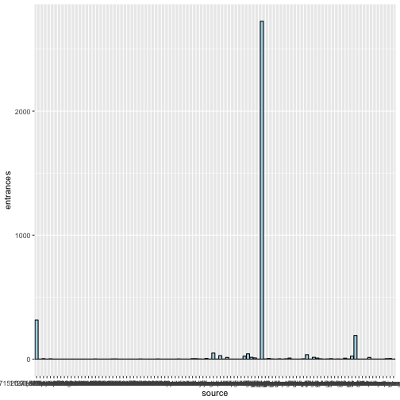

Google generates the biggest amount of new visitors by far

Let's see which media attract great quantities of new visitors

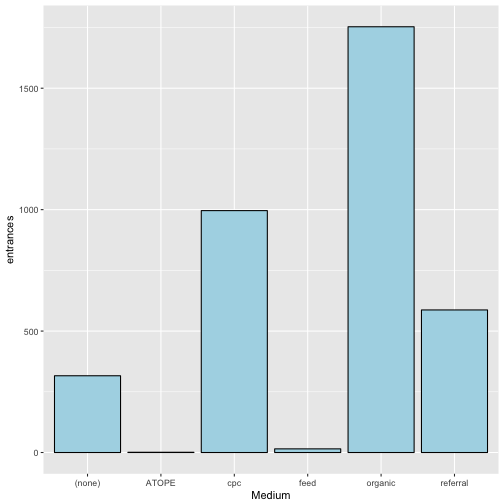

CPC and organic leads from Google account for most of new visitors by far

We can say that organic and CPC media are effective in terms of generating new traffic to the website

Now lets create a subset of data contaning information only for returning visitors and see which sources attract great quantities of returning visitors

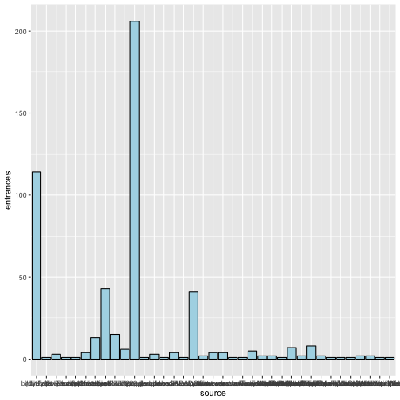

Google generates a greater amount of returning visitors as well (followed by direct)

Let's see which media attract great quantities of returning visitors

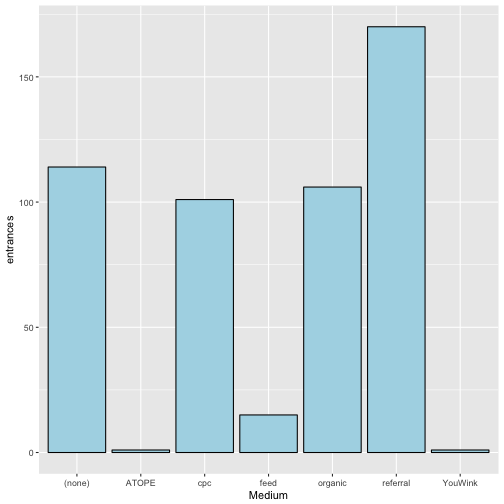

We can say that it is rather innefficient to spend money to attract returning customers through “cpc”. This may be done via less expensive methods (ex. e-mail, targetted referrals etc)

5 When medium is referral, which are the sources that attracted the highest number of pageviews? Based on this, should the author promote the content in any of these websites? Would it be better to invest in visitors coming from the medium 'cpc'?

## *Answer 5*

Let's see which sources attract the highest number of page views when medium is referral

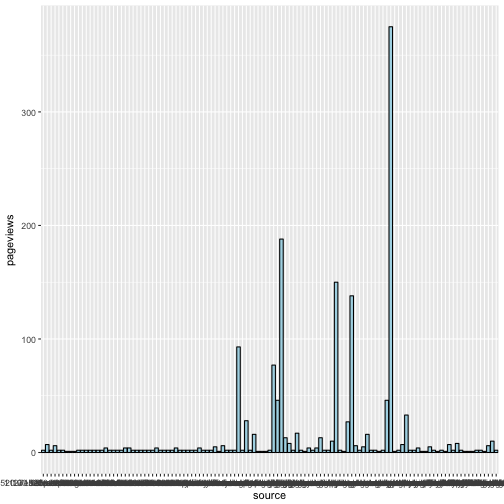

A big part of referrals come fromm semalt.semalt.com which is a technical bot and is not a quality targeted traffic. This floods the statistics with spam visits with 100% bounce rate. Website owners should avoid this referral source by setting properly the website settings (especially if these are paid referrals).

The author of the website should not promote any content on websites which are operated by technical bots.

Facebook and Linked In are #2 and #3 sources in the referral media which indicates the potential attractiveness of these sources. Authors should consider promoting popular and quality content through Facebook and LinkedIn and thus potentially increase the traffic to their website.

Also the website should attend to customer needs by improving free software content and introducing more PHP-related content. This way the website would generate more organic and direct traffic.